# Relatório Técnico: Seleção de Famílias Pró-Produtivas de Cana-de-Açúcar via Aprendizado de Máquina

# 4. Principal Component Regression (PCR)

As an alternative to retaining spectral information without mathematical violations, PCR was implemented.

## PCA Extraction and Analysis of Variance (Scree Plot)

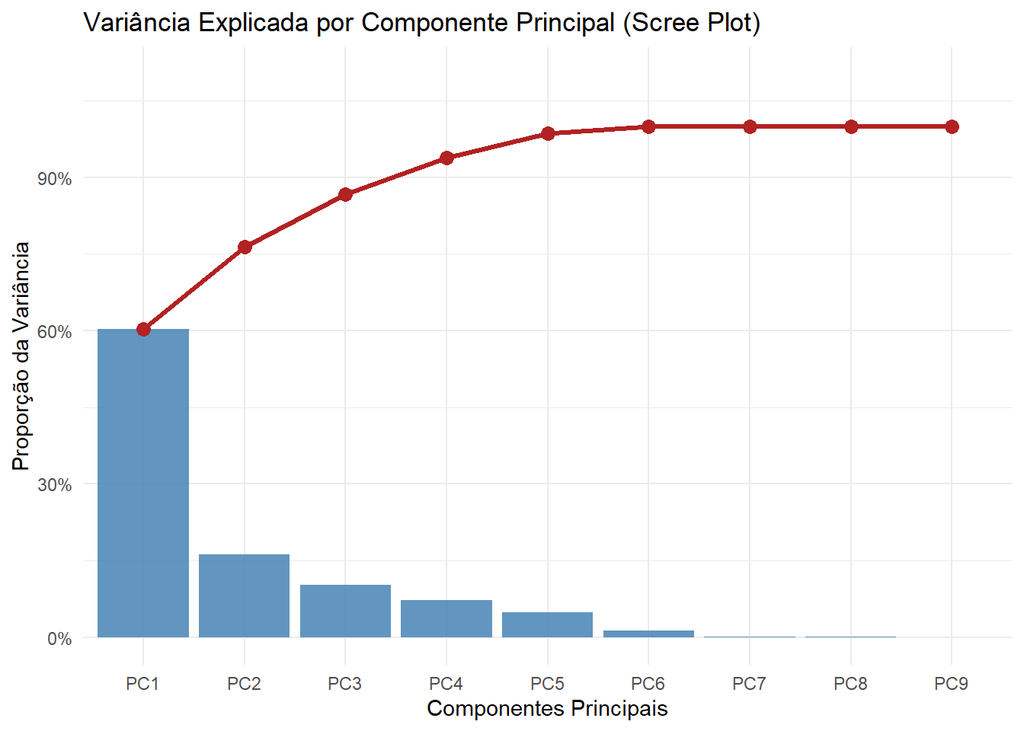

```r
dados_pca_total <- dados %>% select(-Family, -TSH)
pca_total <- prcomp(dados_pca_total, center = TRUE, scale. = TRUE)

var_explicada <- pca_total$sdev^2
prop_var <- var_explicada / sum(var_explicada)
var_acumulada <- cumsum(prop_var)

df_pca_var <- data.frame(
  Componente = factor(paste0("PC", 1:length(prop_var)), levels = paste0("PC", 1:length(prop_var))),
  Proporcao = prop_var,
  Acumulada = var_acumulada
)

ggplot(df_pca_var, aes(x = Componente)) +
  geom_bar(aes(y = Proporcao), stat = "identity", fill = "steelblue", alpha = 0.85) +
  geom_line(aes(y = Acumulada, group = 1), color = "firebrick", linewidth = 1.2) +
  geom_point(aes(y = Acumulada), color = "firebrick", size = 3) +
  scale_y_continuous(labels = scales::percent_format(), limits = c(0, 1.1)) +
  theme_minimal() +
  labs(title = "Variância Explicada por Componente Principal (Scree Plot)",
       x = "Componentes Principais", y = "Proporção da Variância")
```

The decision was made to retain the first 4 components, which account for most of the variability of the original predictors.

## 4.2 PCR Model Adjustment and Stepwise Selection

```r
dados_regressao_pcr <- cbind(dados %>% select(TSH), pca_total$x[, 1:4])
modelo_pcr_total <- lm(TSH ~ PC1 + PC2 + PC3 + PC4, data = dados_regressao_pcr)

# Refinamento Stepwise no modelo PCR
modelo_pcr_refinado <- step(modelo_pcr_total, direction = "both", trace = 0)
summary(modelo_pcr_refinado)
```

```
##
## Call:
## lm(formula = TSH ~ PC1 + PC3 + PC4, data = dados_regressao_pcr)
##
## Residuals:
##     Min      1Q  Median      3Q     Max
## -20.991  -5.856  -1.171   4.310  25.220
##
## Coefficients:
##             Estimate Std. Error t value Pr(>|t|)
## (Intercept) 119.0865     1.0561  112.76  < 2e-16 ***
## PC1          -6.0700     0.4574  -13.27  < 2e-16 ***
## PC3          11.4882     1.1073   10.38 1.18e-14 ***
## PC4         -13.6804     1.3225  -10.35 1.32e-14 ***
## ---
## Signif. codes:  0 '***' 0.001 '**' 0.01 '*' 0.05 '.' 0.1 ' ' 1
##
## Residual standard error: 8.181 on 56 degrees of freedom
## Multiple R-squared:  0.8747, Adjusted R-squared:  0.8679
## F-statistic: 130.3 on 3 and 56 DF,  p-value: < 2.2e-16
```

The *Stepwise* procedure removed **PC2** due to predictive inefficiency. The final refined model (with PC1, PC3, and PC4) preserved the overall fit (Adjusted R² = 86.79%), raising the F-statistic to 130.3. PC2 maps to growth compensation (many thin stalks versus few thick stalks), which alters the architecture but not the final TSH weight.

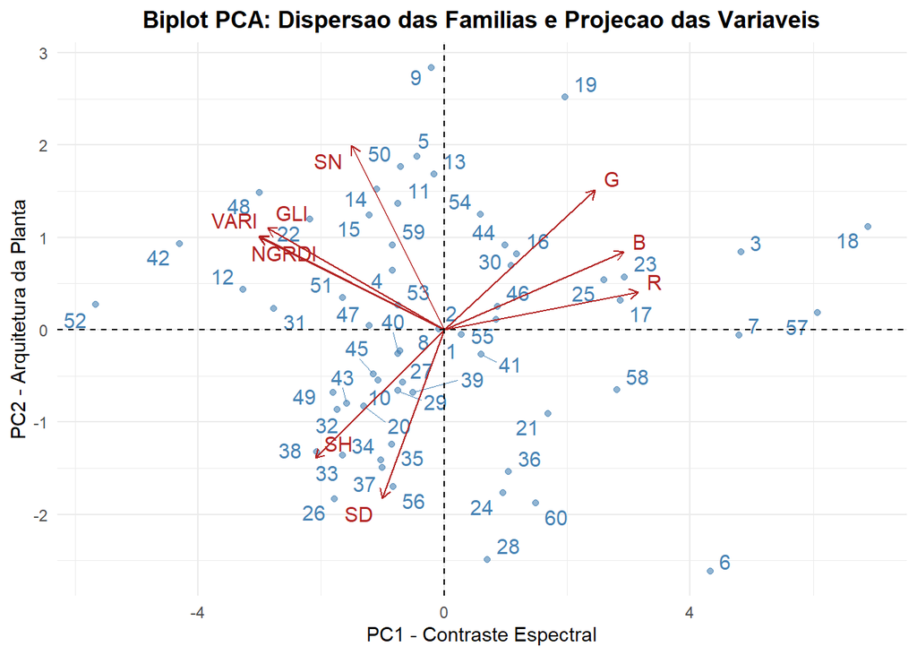

```r
# 1. Carregar o pacote obrigatório para o gráfico
library(factoextra)

# 2. Gerando o Biplot elegante
grafico_biplot <- fviz_pca_biplot(pca_total,
                                  repel = TRUE,                # Evita que os textos se sobreponham
                                  col.var = "firebrick",       # Cor das setas (Variaveis)
                                  col.ind = "steelblue",       # Cor dos pontos (Familias)
                                  alpha.ind = 0.6,             # Transparencia dos pontos
                                  title = "Biplot PCA: Dispersao das Familias e Projecao das Variaveis",
                                  xlab = "PC1 - Contraste Espectral",
                                  ylab = "PC2 - Arquitetura da Planta") +
  theme_minimal() +
  theme(plot.title = element_text(face = "bold", hjust = 0.5))

print(grafico_biplot)
```

Waste analysis

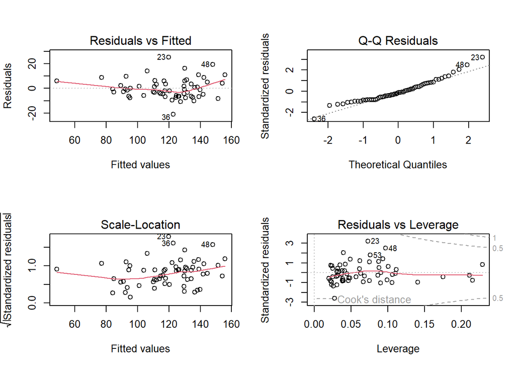

```r
par(mfrow=c(2,2))
plot(modelo_pcr_refinado)
```

```r
library(caret)
library(dplyr)
library(knitr)

set.seed(123)

# 1. Configurando os métodos de Validação Cruzada
controle_kfold <- trainControl(method = "cv", number = 10)
controle_loocv <- trainControl(method = "LOOCV")

# 2. Treinando o modelo com 10-Fold CV
# Usando o modelo refinado: TSH em função dos componentes que sobreviveram
modelo_kfold <- train(
  TSH ~ PC1 + PC3 + PC4,
  data = dados_regressao_pcr,
  method = "lm",
  trControl = controle_kfold
)

# 3. Treinando o modelo com Leave-One-Out (LOOCV)
modelo_loocv <- train(
  TSH ~ PC1 + PC3 + PC4,
  data = dados_regressao_pcr,
  method = "lm",
  trControl = controle_loocv
)

# 4. Extraindo as métricas de cada modelo para comparar
metricas_kfold <- modelo_kfold$results %>% select(RMSE, Rsquared, MAE)
metricas_loocv <- modelo_loocv$results %>% select(RMSE, Rsquared, MAE)

# 5. Criando um Dataframe de comparação
tabela_comparacao <- rbind(
  "10-Fold CV" = metricas_kfold,
  "LOOCV (Deixa um de fora)" = metricas_loocv
)

# 6. Imprimindo a tabela formatada
kable(tabela_comparacao,
      caption = "Comparação de Métricas de Validação Cruzada: 10-Fold vs LOOCV",
      digits = 3,
      align = "c")
```

Comparação de Métricas de Validação Cruzada: 10-Fold vs LOOCV

|  | RMSE | Rsquared | MAE |
| --- | --- | --- | --- |
| 10-Fold CV | 7.713 | 0.855 | 6.403 |
| LOOCV (Deixa um de fora) | 8.458 | 0.857 | 6.551 |

```r
# Carregando os pacotes necessários
library(caret)
library(ggplot2)
library(dplyr)
library(knitr)

# Garantindo a reprodutibilidade da separação dos dados no 10-Fold
set.seed(123)
controle_kfold <- trainControl(method = "cv", number = 10)

# Criando um dataframe vazio para guardar os resultados
resultados_poly <- data.frame(Grau = integer(), RMSE = numeric(), Rsquared = numeric())

# Loop para testar polinômios do Grau 1 ao Grau 4
for (grau in 1:4) {

  # Criando a fórmula dinamicamente para o grau atual
  # Exemplo no grau 2: TSH ~ poly(PC1, 2) + poly(PC3, 2) + poly(PC4, 2)
  formula_poly <- as.formula(paste0("TSH ~ poly(PC1, ", grau, ") + poly(PC3, ", grau, ") + poly(PC4, ", grau, ")"))

  # Treinando o modelo com 10-Fold CV
  modelo_temp <- train(
    formula_poly,
    data = dados_regressao_pcr,
    method = "lm",
    trControl = controle_kfold
  )

  # Guardando as métricas de validação deste grau
  resultados_poly <- rbind(resultados_poly, data.frame(
    Grau = grau,
    RMSE = modelo_temp$results$RMSE,
    Rsquared = modelo_temp$results$Rsquared
  ))
}

kable(resultados_poly,
      caption = "Desempenho da Validação Cruzada (10-Fold) por Grau do Polinômio",
      digits = 3, align = "c")
```

Desempenho da Validação Cruzada (10-Fold) por Grau do Polinômio

| Grau | RMSE | Rsquared |
| --- | --- | --- |
| 1 | 7.713 | 0.855 |
| 2 | 8.174 | 0.884 |
| 3 | 11.235 | 0.782 |
| 4 | 11.498 | 0.838 |